# C4TS R-Club - Session 1

We can add axis to the plot using the following terms

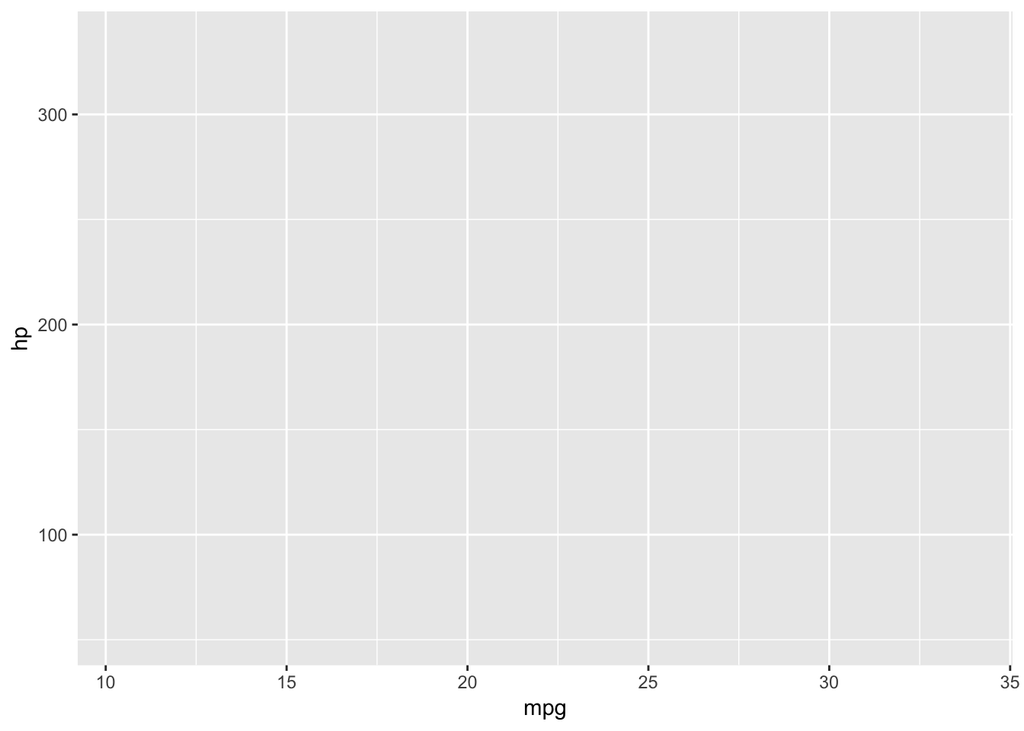

```r
ggplot(data = mtcars, mapping = aes(x = mpg, y = hp))
```

Then we can add a visualisation of the data in question by using a geom. Note that to do this, we chain a new line onto the ggplot function using the + symbol

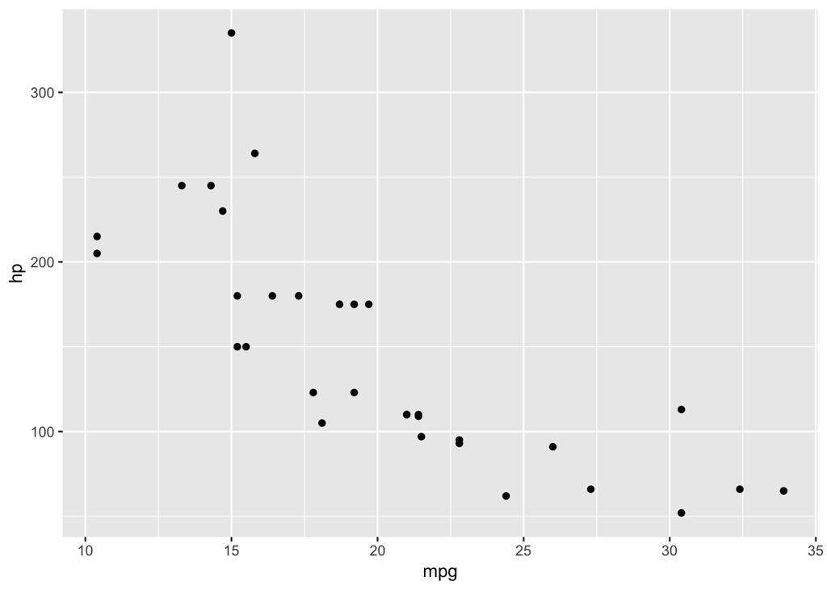

```r
ggplot(data=mtcars, mapping = aes(x = mpg, y = hp)) +
  geom_point()
```

We can add labels and annotations using the labs function

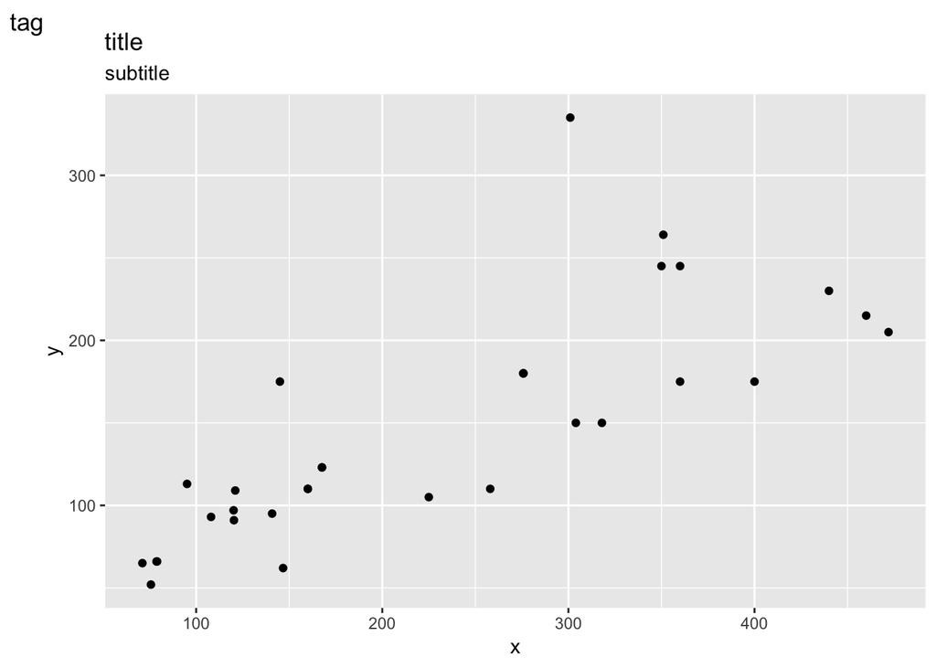

```r
ggplot(data=mtcars, mapping = aes(x = disp, y = hp)) +
  geom_point() +
  labs(title = "title", y = "y", x = "x", subtitle = "subtitle", tag = "tag")
```

And some color using the color/colour variable of mapping

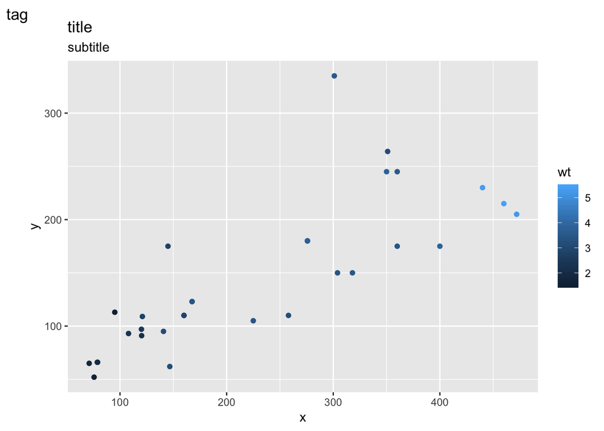

```r
ggplot(data=mtcars, mapping = aes(x = disp, y = hp, color = wt)) +
  geom_point() +
  labs(title = "title", y = "y", x = "x", subtitle = "subtitle", tag = "tag")
```

There are numerous types of Geom which can be used in ggplot a full list can be seen on the ggplot [reference pages](https://ggplot2.tidyverse.org)

Each geom has default statistical transformation included as a default behaviour.

Using the diamonds data set we can produce a histogram of the number of diamonds by cut.

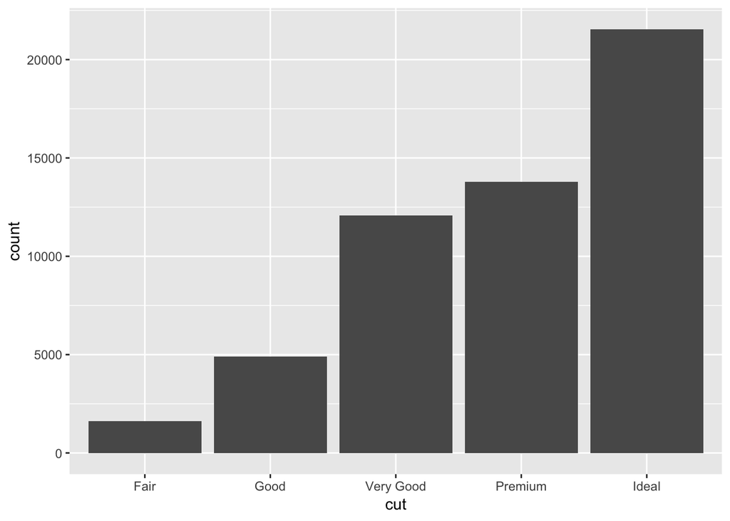

```r
ggplot(data = diamonds, mapping = aes(x = cut)) +
  geom_bar()
```

Note that in the above graph we have not given R any information about the number of each diamond. Just that we want a bar chart where the x axis is cut and the data set was diamonds.

The default statistic used by geom_bar is count, read more about geom_bar and any R function using ?functionname i.e. `{r ?geom_bar`

If we wanted to make the same graph using data where we had already calculated the counts of variables we would need to change the way we use geom_bar.

In the next code chunk I have calculated a tally of diamonds by their cut.

```r
test <- diamonds %>%
  group_by(cut) %>%
  tally()


# The next function just presents the data in a table
kable(test, "html") %>%
  kable_styling(bootstrap_options = "striped", full_width = F)
```

| cut | n |
| --- | --- |
| Fair | 1610 |
| Good | 4906 |
| Very Good | 12082 |
| Premium | 13791 |
| Ideal | 21551 |

if we pass this to ggplot as we did before we get a graph that looks nothing like what we were expecting.

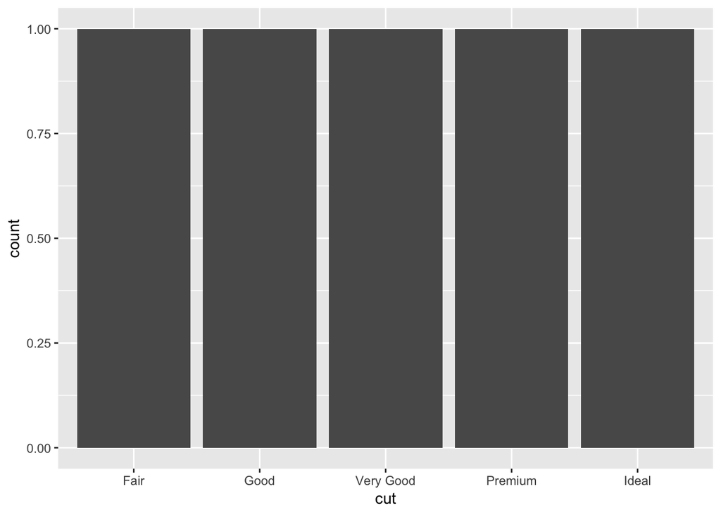

```r
ggplot(data = test, mapping = aes(x = cut)) +
  geom_bar()
```

This is because the stat for geom_bar has used count and so counted the number of rows where each cut type can be found. As each cut type appears only once the resulting value is one for each cut.

The correct way to pass the values to ggplot for the formating of the graph is shown below but importantly stat = “identity” is used in the function call to geom_bar to tell it to use the values in n and not calculate these.

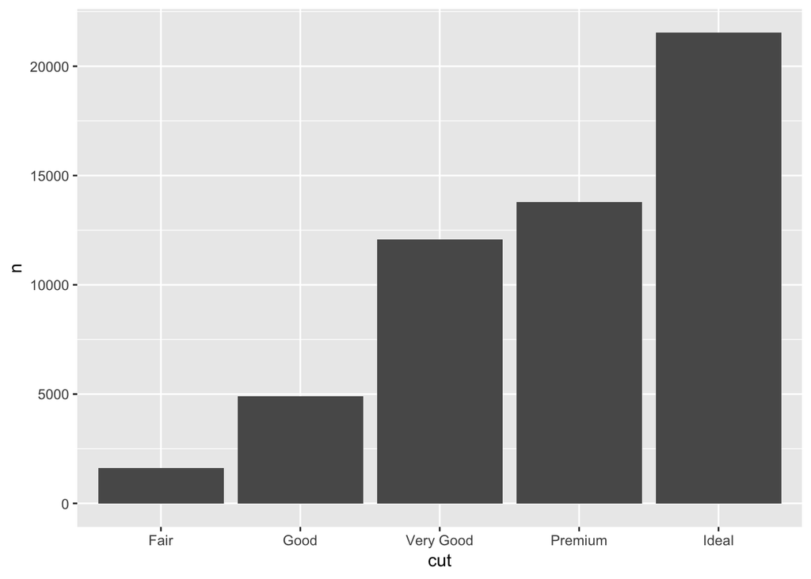

```r
# I am trying to show the default statistics functions of geoms
ggplot(data = test, mapping = aes(x = cut, y=n)) +
  geom_bar(stat = "identity")
```

## Loading data into R

Loading data into R requires a consistent approach.

you need to know the precise location of a file path (the location where a file is stored) and you need to give this to R in a way that it can understand based on the current working directory.

```r
getwd()
```

```
## [1] "/Users/jason/R/r4ds/01. Session 1 "
```

getwd() returns the current working directory where R is being used. When working in Rmarkdown documents it will typically be where ever the rmarkdown document is saved.

To make things easy when starting out create a new project folder for each project that you are working on and keep your data files in the same location.

The read.csv function can be used to read in files in csv format and it comes from the readr package which is part of the tidyverse.

```r
read.csv(file = "test.csv", header = FALSE) -> data
print(data)
```

```
##   V1 V2
## 1  1  a
## 2  2  b
## 3  3  c
```

Next session we will be covering: - [ ] working in projects  
- [ ] loading data files  
- [ ] data calculations  
- [ ] graph something  
- [ ] create a table